# Part II - ProsperLoan Exploration

## by Kwadwo Addo

## Investigation Overview

> My goal of this investigation is to find the determining relationships between features that can determine if a loan will be completed or defaulted.

## Dataset Overview

> This data set contains 113,937 loans with 81 variables on each loan, including loan amount, borrower rate, current loan status, borrower income, and others.

## ProsperScore and LoanStatus

> This visualization shows the relationship between the ProsperScore and the LoanStatus. It shows the number of completed or defaulted loans per ProsperScore.

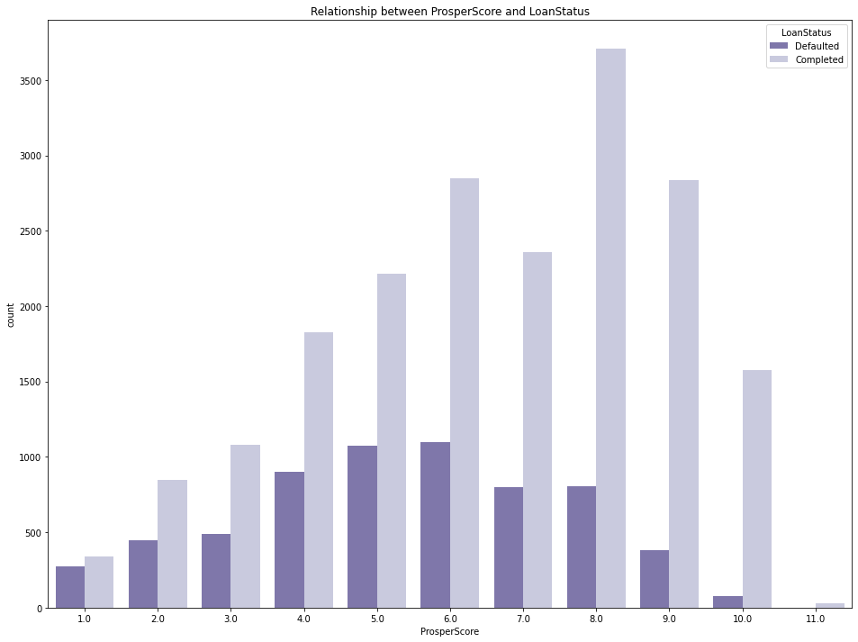

```python
plt.figure(figsize = [16, 12])
plt.title("Relationship between ProsperScore and LoanStatus")
sb.countplot(data = focused_loan_dataframe, x = 'ProsperScore', hue = 'LoanStatus', palette = 'Purples_r');
```

## ListingCategory and LoanStatus

> This visualization shows the relationship between the ListingCategory and the LoanStatus. It shows the number of loans that are completed or defauted for each type of loan in the category.

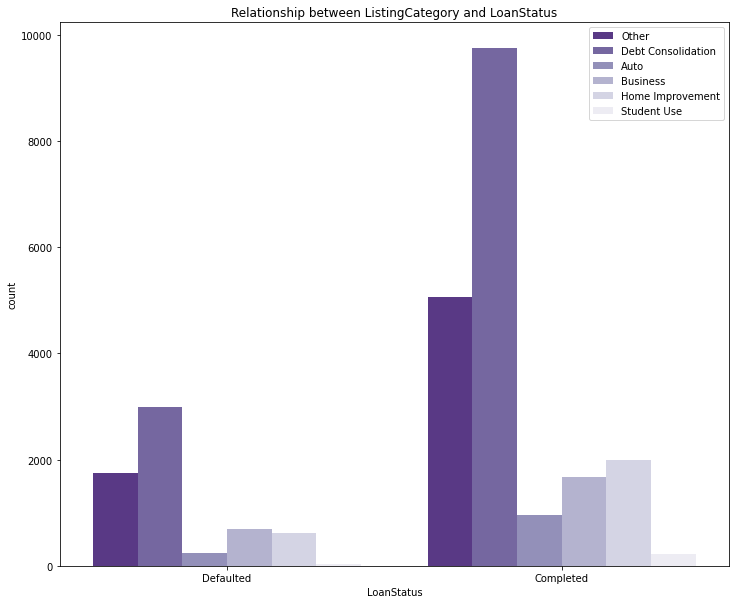

```python
plt.figure(figsize = [12, 10])
plt.title("Relationship between ListingCategory and LoanStatus")
sb.countplot(data = focused_loan_dataframe, x = 'LoanStatus', hue = 'ListingCategory', palette = 'Purples_r')
plt.legend(loc='upper right');
```